# PCoulibaly: Final Project

```r
recession = read.csv("africa_recession.csv", stringsAsFactors = TRUE)
```

# Section 1. Data Cleaning

1. The recession data frame has 486 observations with 50 variables. All the variables are continuous variables except the target variable growthbucket which is a categorical variable. The 0 in the target variable represent a “no” while a “1” is a yes for recession based on the data description.

```r
str(recession)
```

```
'data.frame':   486 obs. of  50 variables:
 $ pop                   : num  28.85 45.73 33.26 8.03 1.06 ...
 $ emp                   : num  6.914 13.624 13.324 3.869 0.243 ...
 $ emp_to_pop_ratio      : num  0.24 0.298 0.401 0.482 0.229 ...
 $ hc                    : num  1.55 2.09 1.5 1.36 1.68 ...
 $ ccon                  : num  99010 316863 29763 6489 7620 ...
 $ cda                   : num  131991 374842 36585 7007 8419 ...
 $ cn                    : num  426543 804602 67073 5790 16907 ...
 $ ck                    : num  0.009374 0.019658 0.00167 0.000184 0.000431 ...
 $ ctfp                  : num  0.649 0.719 0.309 0.206 0.96 ...
 $ cwtfp                 : num  0.626 0.658 0.293 0.235 0.994 ...
 $ rconna                : num  95643 308969 36393 7097 5540 ...
 $ rdana                 : num  131824 379570 43032 7673 7003 ...
 $ rnna                  : num  703953 1669636 161644 10142 41004 ...
 $ rkna                  : num  0.513 0.647 0.4 0.45 1.068 ...
```

[output cut: 36 more lines]

The summary of the data frame confirms the number of observation and number of variables as well as the fact that all the variables are continuous except the target variable growthbucket

```r
summary(recession)
```

```
      pop               emp         emp_to_pop_ratio       hc             ccon
 Min.   :  1.061   Min.   : 0.243   Min.   :0.1982   Min.   :1.069   Min.   :  2781
 1st Qu.:  3.831   1st Qu.: 1.049   1st Qu.:0.2979   1st Qu.:1.446   1st Qu.:  9117
 Median : 10.868   Median : 4.184   Median :0.3688   Median :1.690   Median : 17472
 Mean   : 20.186   Mean   : 7.121   Mean   :0.3579   Mean   :1.777   Mean   : 64361
 3rd Qu.: 24.221   3rd Qu.: 8.518   3rd Qu.:0.4167   3rd Qu.:2.117   3rd Qu.: 58017
 Max.   :190.886   Max.   :65.157   Max.   :0.5554   Max.   :2.885   Max.   :758455
      cda               cn                ck                 ctfp             cwtfp
 Min.   :  2984   Min.   :   5790   Min.   :0.0001238   Min.   :0.09862   Min.   :0.1078
 1st Qu.: 11082   1st Qu.:  24292   1st Qu.:0.0005139   1st Qu.:0.30118   1st Qu.:0.2956
 Median : 22228   Median :  64324   Median :0.0013554   Median :0.40065   Median :0.4059
 Mean   : 80886   Mean   : 244224   Mean   :0.0045827   Mean   :0.45442   Mean   :0.4534
 3rd Qu.: 69677   3rd Qu.: 188624   3rd Qu.:0.0032271   3rd Qu.:0.61674   3rd Qu.:0.6035
 Max.   :896605   Max.   :2886312   Max.   :0.0418350   Max.   :0.99819   Max.   :1.0317
     rconna           rdana             rnna              rkna            rtfpna
 Min.   :  2787   Min.   :  2978   Min.   :   8736   Min.   :0.1368   Min.   :0.4295
 1st Qu.:  8798   1st Qu.: 10661   1st Qu.:  34658   1st Qu.:0.7100   1st Qu.:0.9470
 Median : 16610   Median : 21656   Median :  74131   Median :0.9334   Median :1.0000
 Mean   : 68170   Mean   : 86895   Mean   : 296093   Mean   :0.9220   Mean   :0.9889
 3rd Qu.: 61146   3rd Qu.: 81661   3rd Qu.: 248804   3rd Qu.:1.0374   3rd Qu.:1.0385
 Max.   :762127   Max.   :908561   Max.   :2592378   Max.   :3.0339   Max.   :1.9568
    rwtfpna           labsh             irr              delta               xr
 Min.   :0.3829   Min.   :0.1643   Min.   :0.01000   Min.   :0.02487   Min.   :   1.000
 1st Qu.:0.9006   1st Qu.:0.4261   1st Qu.:0.06337   1st Qu.:0.04125   1st Qu.:   8.609
 Median :0.9788   Median :0.5233   Median :0.10755   Median :0.04632   Median : 152.080
 Mean   :0.9562   Mean   :0.5132   Mean   :0.11596   Mean   :0.04809   Mean   : 447.069
 3rd Qu.:1.0154   3rd Qu.:0.6121   3rd Qu.:0.16136   3rd Qu.:0.05274   3rd Qu.: 550.521
 Max.   :1.4473   Max.   :0.8373   Max.   :0.43007   Max.   :0.09394   Max.   :7384.432
     pl_con           pl_da           pl_gdpo           csh_c            csh_i
 Min.   :0.1502   Min.   :0.1468   Min.   :0.1287   Min.   :0.2237   Min.   :0.04995
 1st Qu.:0.3385   1st Qu.:0.3492   1st Qu.:0.3294   1st Qu.:0.5944   1st Qu.:0.14212
 Median :0.4093   Median :0.4226   Median :0.4085   Median :0.7083   Median :0.19326
 Mean   :0.4205   Mean   :0.4250   Mean   :0.4116   Mean   :0.6794   Mean   :0.20677
 3rd Qu.:0.4902   3rd Qu.:0.4892   3rd Qu.:0.4871   3rd Qu.:0.7927   3rd Qu.:0.26834
 Max.   :0.9286   Max.   :0.8663   Max.   :0.8099   Max.   :0.9995   Max.   :0.55603
     csh_g             csh_x             csh_m              csh_r                pl_c
 Min.   :0.01655   Min.   :0.01221   Min.   :-0.78446   Min.   :-0.652756   Min.   :0.1546
 1st Qu.:0.13208   1st Qu.:0.05993   1st Qu.:-0.29967   1st Qu.:-0.034658   1st Qu.:0.3467
 Median :0.16864   Median :0.13685   Median :-0.18637   Median : 0.000000   Median :0.4162
 Mean   :0.17406   Mean   :0.16854   Mean   :-0.22568   Mean   :-0.003049   Mean   :0.4307
```

[output cut: 15 more lines]

```
 Max.   :689.9   Max.   :415.2   Max.   :1985.5   Max.   :775.1   Max.   :417.6   Max.   :308.1
      fish         total_change      excl_energy_change energy_change      metals_minerals_change
 Min.   : 843.7   Min.   :-0.35945   Min.   :-0.17374   Min.   :-0.47702   Min.   :-0.15756
 1st Qu.: 899.2   1st Qu.:-0.05893   1st Qu.:-0.04432   1st Qu.:-0.10294   1st Qu.:-0.05340
 Median : 948.7   Median : 0.06186   Median : 0.01995   Median : 0.05493   Median : 0.04681
 Mean   :1009.4   Mean   : 0.04454   Mean   : 0.03035   Mean   : 0.08241   Mean   : 0.05814
 3rd Qu.:1095.3   3rd Qu.: 0.20873   3rd Qu.: 0.10579   3rd Qu.: 0.24509   3rd Qu.: 0.15453
 Max.   :1276.5   Max.   : 0.26484   Max.   : 0.21835   Max.   : 0.71719   Max.   : 0.47620
 forestry_change     agriculture_change  fish_change         growthbucket
 Min.   :-0.174550   Min.   :-0.22600   Min.   :-0.113858   Min.   :0.00000
 1st Qu.:-0.060792   1st Qu.:-0.02645   1st Qu.:-0.020995   1st Qu.:0.00000
 Median : 0.003277   Median : 0.03844   Median : 0.006529   Median :0.00000
 Mean   : 0.024774   Mean   : 0.03393   Mean   : 0.023741   Mean   :0.07819
 3rd Qu.: 0.096810   3rd Qu.: 0.11279   3rd Qu.: 0.047421   3rd Qu.:0.00000
 Max.   : 0.300217   Max.   : 0.32088   Max.   : 0.165440   Max.   :1.00000
```

2. It appears that there are no missing values in this data set.

```r
colSums(is.na(recession))
```

```
                   pop                    emp       emp_to_pop_ratio                     hc
                     0                      0                      0                      0
                  ccon                    cda                     cn                     ck
                     0                      0                      0                      0
                  ctfp                  cwtfp                 rconna                  rdana
                     0                      0                      0                      0
                  rnna                   rkna                 rtfpna                rwtfpna
                     0                      0                      0                      0
                 labsh                    irr                  delta                     xr
                     0                      0                      0                      0
                pl_con                  pl_da                pl_gdpo                  csh_c
                     0                      0                      0                      0
                 csh_i                  csh_g                  csh_x                  csh_m
                     0                      0                      0                      0
                 csh_r                   pl_c                   pl_i                   pl_g
                     0                      0                      0                      0
                  pl_x                   pl_m                   pl_n                  total
                     0                      0                      0                      0
           excl_energy                 energy        metals_minerals               forestry
                     0                      0                      0                      0
           agriculture                   fish           total_change     excl_energy_change
                     0                      0                      0                      0
         energy_change metals_minerals_change        forestry_change     agriculture_change
                     0                      0                      0                      0
           fish_change           growthbucket
                     0                      0
```

It is not unusual for NA to be entered as “?”. Checking for those in the data set confirms that the rows are pretty clean when it comes to missing values.

```r
colSums(recession == "?")
```

```
                   pop                    emp       emp_to_pop_ratio                     hc
                     0                      0                      0                      0
                  ccon                    cda                     cn                     ck
                     0                      0                      0                      0
                  ctfp                  cwtfp                 rconna                  rdana
                     0                      0                      0                      0
                  rnna                   rkna                 rtfpna                rwtfpna
                     0                      0                      0                      0
                 labsh                    irr                  delta                     xr
                     0                      0                      0                      0
                pl_con                  pl_da                pl_gdpo                  csh_c
                     0                      0                      0                      0
                 csh_i                  csh_g                  csh_x                  csh_m
                     0                      0                      0                      0
                 csh_r                   pl_c                   pl_i                   pl_g
                     0                      0                      0                      0
                  pl_x                   pl_m                   pl_n                  total
                     0                      0                      0                      0
           excl_energy                 energy        metals_minerals               forestry
                     0                      0                      0                      0
           agriculture                   fish           total_change     excl_energy_change
                     0                      0                      0                      0
         energy_change metals_minerals_change        forestry_change     agriculture_change
                     0                      0                      0                      0
           fish_change           growthbucket
                     0                      0
```

3. Since the target variable is a categorical variable, for simplicity of read I will change the variable to a 2 level factor. I will revert the change when training the ANN model. The 0 to a “no” and the 1 to a “yes”. A “no” level means there is no recession in that particular country while a “yes” would mean there is a recession.

```r
recession$growthbucket = ifelse(recession$growthbucket == 0, "no", "yes")
recession$growthbucket = as.factor(recession$growthbucket)
```

#Section 2. Data Exploration

4. It is clear that the outcome variable is imbalanced having 92.1% of no response and 7.8% of yes. The imbalance issue will be addressed before training our models.

```r
table(recession$growthbucket)
```

[output not shown]

```r
prop.table(table(recession$growthbucket)) *100
```

[output not shown]

5. I am going to examine the relationship between the outcome variable and all continous variables. A set of side by side box plots will be used for that purpose. I will also use a manova test to examine that relationship.

```r
install.packages("psych")
library(psych)
attach(recession)
```

1. The observations from the box plots observations indicates there might be a slight difference with hc, and a significant difference with emp_to_pop_ratio, cwtfp and ctfp.

```r
par(mfcol=c(3,4))
plot(pop ~ growthbucket, main = "pop")
plot(emp ~ growthbucket, main = "emp")
```

```r
plot(emp_to_pop_ratio ~ growthbucket, main = "emp_to_pop_ratio")
plot(hc ~ growthbucket, main = "hc")
```

```r
plot(ccon ~ growthbucket, main = "ccon")
plot(cda ~ growthbucket, main = "cda")
```

```r
plot(cn ~ growthbucket, main = "cn")
plot(ck ~ growthbucket, main = "ck")
```

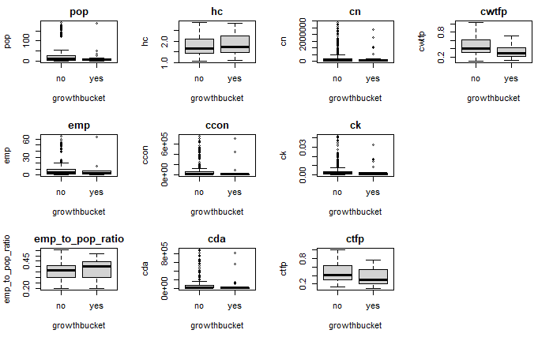

```r
plot(ctfp ~ growthbucket, main = "ctfp")
plot(cwtfp ~ growthbucket, main = "cwtfp")
```

2. However, the t-test determines that hc and emp_to_pop_ratio do not have a significance due to their p-value being over 0.05. Only ctfp and cwtfp have a confirmed significant difference.

```r
test1 = manova(cbind(pop, emp, emp_to_pop_ratio, hc, ccon, cda, cn, ck, ctfp, cwtfp) ~ growthbucket, data = recession)

summary.aov(test1)
```

```
 Response pop :
              Df Sum Sq Mean Sq F value Pr(>F)
growthbucket   1   1154 1153.55  1.2793 0.2586
Residuals    484 436438  901.73

 Response emp :
              Df Sum Sq Mean Sq F value Pr(>F)
growthbucket   1     92  91.511  0.9295 0.3355
Residuals    484  47650  98.450

 Response emp_to_pop_ratio :
              Df  Sum Sq   Mean Sq F value Pr(>F)
growthbucket   1 0.01683 0.0168280  2.6028 0.1073
Residuals    484 3.12929 0.0064655

 Response hc :
              Df Sum Sq Mean Sq F value Pr(>F)
growthbucket   1  0.233 0.23294  1.1697   0.28
Residuals    484 96.388 0.19915

 Response ccon :
              Df     Sum Sq    Mean Sq F value Pr(>F)
growthbucket   1 9.3013e+09 9.3013e+09   0.553 0.4575
Residuals    484 8.1412e+12 1.6821e+10

 Response cda :
              Df     Sum Sq    Mean Sq F value Pr(>F)
growthbucket   1 1.4001e+10 1.4001e+10  0.5694 0.4509
Residuals    484 1.1901e+13 2.4589e+10

 Response cn :
              Df     Sum Sq    Mean Sq F value Pr(>F)
growthbucket   1 6.9414e+09 6.9414e+09   0.031 0.8603
Residuals    484 1.0828e+14 2.2372e+11

 Response ck :
              Df   Sum Sq    Mean Sq F value Pr(>F)
growthbucket   1 0.000012 1.2456e-05  0.1845 0.6677
Residuals    484 0.032678 6.7516e-05

 Response ctfp :
              Df  Sum Sq Mean Sq F value   Pr(>F)
growthbucket   1  0.3921 0.39215  9.3488 0.002355 **
Residuals    484 20.3018 0.04195
---
Signif. codes:  0 ‘***’ 0.001 ‘**’ 0.01 ‘*’ 0.05 ‘.’ 0.1 ‘ ’ 1

 Response cwtfp :
              Df  Sum Sq Mean Sq F value    Pr(>F)
growthbucket   1  0.5365 0.53649  13.343 0.0002877 ***
Residuals    484 19.4610 0.04021
---
Signif. codes:  0 ‘***’ 0.001 ‘**’ 0.01 ‘*’ 0.05 ‘.’ 0.1 ‘ ’ 1
```

3. There are slight differences between growthbucket and labsh, rwtfpna, delta.

```r
par(mfcol=c(3,4))
plot(rconna ~ growthbucket, main = "rconna")
plot(rdana ~ growthbucket, main = "rdana")
```

```r
plot(rnna ~ growthbucket, main = "rnna")
plot(rkna ~ growthbucket, main = "rkna")
```

```r
plot(rtfpna ~ growthbucket, main = "rtfpna")
plot(rwtfpna ~ growthbucket, main = "rwtfpna")
```

```r
plot(labsh ~ growthbucket, main = "labsh")
plot(irr ~ growthbucket, main = "irr")
```

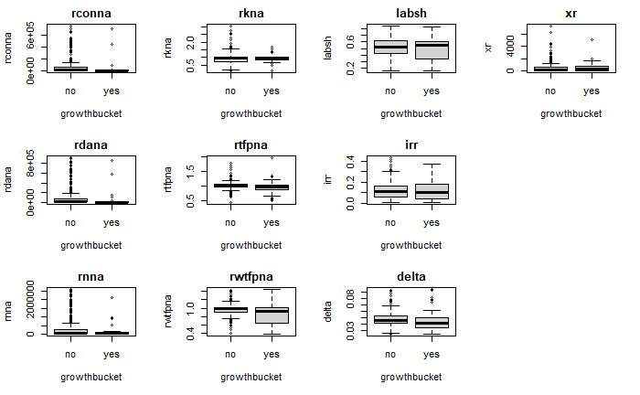

```r
plot(delta ~ growthbucket, main = "delta")
plot(xr ~ growthbucket, main = "xr")
```

4. The t-test indicates only rwtfpna has a statistical difference with growthbucket.

```r
test2 = manova(cbind(rconna, rdana, rnna, rkna, rtfpna, rwtfpna, labsh, irr, delta, xr) ~ growthbucket, data = recession)

summary.aov(test2)
```

```
 Response rconna :
              Df     Sum Sq    Mean Sq F value Pr(>F)
growthbucket   1 1.7148e+10 1.7148e+10  0.9222 0.3374
Residuals    484 8.9999e+12 1.8595e+10

 Response rdana :
              Df     Sum Sq    Mean Sq F value Pr(>F)
growthbucket   1 2.6543e+10 2.6543e+10  0.9762 0.3236
Residuals    484 1.3160e+13 2.7191e+10

 Response rnna :
              Df     Sum Sq    Mean Sq F value Pr(>F)
growthbucket   1 1.5745e+11 1.5745e+11  0.5986 0.4395
Residuals    484 1.2729e+14 2.6300e+11

 Response rkna :
              Df Sum Sq  Mean Sq F value Pr(>F)
growthbucket   1  0.000 0.000217  0.0019 0.9655
Residuals    484 56.157 0.116028

 Response rtfpna :
              Df Sum Sq  Mean Sq F value Pr(>F)
growthbucket   1 0.0539 0.053913  2.6275 0.1057
Residuals    484 9.9309 0.020518

 Response rwtfpna :
              Df Sum Sq Mean Sq F value    Pr(>F)
growthbucket   1 0.4628 0.46281  24.453 1.052e-06 ***
Residuals    484 9.1603 0.01893
---
Signif. codes:  0 ‘***’ 0.001 ‘**’ 0.01 ‘*’ 0.05 ‘.’ 0.1 ‘ ’ 1

 Response labsh :
              Df  Sum Sq   Mean Sq F value Pr(>F)
growthbucket   1  0.0003 0.0002999  0.0135 0.9076
Residuals    484 10.7560 0.0222231

 Response irr :
              Df  Sum Sq   Mean Sq F value Pr(>F)
growthbucket   1 0.00007 0.0000677  0.0124 0.9112
Residuals    484 2.63360 0.0054413

 Response delta :
              Df   Sum Sq    Mean Sq F value Pr(>F)
growthbucket   1 0.000084 0.00008417  0.5684 0.4513
Residuals    484 0.071669 0.00014808

 Response xr :
              Df    Sum Sq Mean Sq F value Pr(>F)
growthbucket   1    401446  401446  0.6311 0.4273
Residuals    484 307875435  636106
```

5. There are also slight significant difference with csh_x, pl_c, csh_i, csh_m, csh_g, csh_r and the outcome variable.

```r
par(mfcol=c(3,4))
plot(pl_con ~ growthbucket, main = "pl_con")
plot(pl_da ~ growthbucket, main = "pl_da")
```

```r
plot(pl_gdpo ~ growthbucket, main = "pl_gdpo")
plot(csh_c ~ growthbucket, main = "csh_c")
```

```r
plot(csh_i ~ growthbucket, main = "csh_i")
plot(csh_g ~ growthbucket, main = "csh_g")
```

```r
plot(csh_x ~ growthbucket, main = "csh_x")
plot(csh_m ~ growthbucket, main = "csh_m")
```

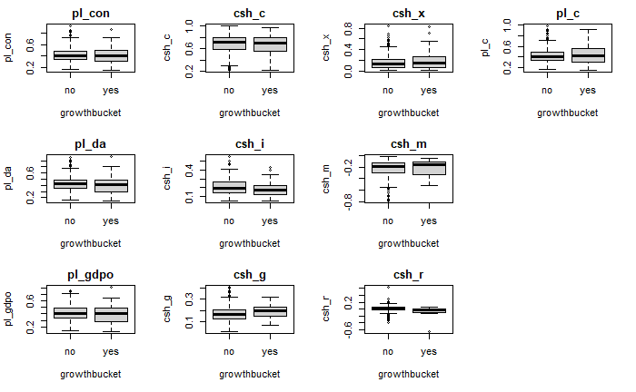

```r
plot(csh_r ~ growthbucket, main = "csh_r")
plot(pl_c ~ growthbucket, main = "pl_c")
```

6. The t-test shows that only csh_g and csh_r have a statistical difference with growthbucket based on the alpha-value of being less than 0.05.

```r
test3 = manova(cbind(pl_con, pl_da, pl_gdpo, csh_c, csh_i, csh_g, csh_x, csh_m, csh_r, pl_c) ~ growthbucket, data = recession)

summary.aov(test3)
```

```
 Response pl_con :
              Df Sum Sq   Mean Sq F value Pr(>F)
growthbucket   1 0.0005 0.0004852  0.0304 0.8617
Residuals    484 7.7293 0.0159696

 Response pl_da :
              Df Sum Sq   Mean Sq F value Pr(>F)
growthbucket   1 0.0082 0.0082252  0.5996 0.4391
Residuals    484 6.6391 0.0137171

 Response pl_gdpo :
              Df Sum Sq   Mean Sq F value Pr(>F)
growthbucket   1 0.0068 0.0067824  0.4927 0.4831
Residuals    484 6.6626 0.0137658

 Response csh_c :
              Df  Sum Sq  Mean Sq F value Pr(>F)
growthbucket   1  0.0291 0.029080   1.152 0.2837
Residuals    484 12.2172 0.025242

 Response csh_i :
              Df Sum Sq   Mean Sq F value Pr(>F)
growthbucket   1 0.0115 0.0115347  1.4578 0.2279
Residuals    484 3.8296 0.0079124

 Response csh_g :
              Df  Sum Sq   Mean Sq F value Pr(>F)
growthbucket   1 0.02538 0.0253848  6.4509 0.0114 *
Residuals    484 1.90457 0.0039351
---
Signif. codes:  0 ‘***’ 0.001 ‘**’ 0.01 ‘*’ 0.05 ‘.’ 0.1 ‘ ’ 1

 Response csh_x :
              Df Sum Sq  Mean Sq F value  Pr(>F)
growthbucket   1 0.0549 0.054909   2.718 0.09987 .
Residuals    484 9.7778 0.020202
---
Signif. codes:  0 ‘***’ 0.001 ‘**’ 0.01 ‘*’ 0.05 ‘.’ 0.1 ‘ ’ 1

 Response csh_m :
              Df Sum Sq  Mean Sq F value Pr(>F)
growthbucket   1 0.0332 0.033205  1.8935 0.1694
Residuals    484 8.4874 0.017536

 Response csh_r :
              Df Sum Sq  Mean Sq F value    Pr(>F)
growthbucket   1 0.0888 0.088774  11.157 0.0009019 ***
Residuals    484 3.8511 0.007957
---
Signif. codes:  0 ‘***’ 0.001 ‘**’ 0.01 ‘*’ 0.05 ‘.’ 0.1 ‘ ’ 1

 Response pl_c :
              Df Sum Sq  Mean Sq F value Pr(>F)
growthbucket   1 0.0243 0.024341  1.3154  0.252
Residuals    484 8.9562 0.018505
```

7. There are slight differences with pl_i, pl_m, pl_x and metals_minerals. There appears to be a more significant difference with the rest of the features except pl_n.

```r
par(mfcol=c(3,4))
plot(pl_i ~ growthbucket, main = "pl_i")
plot(pl_g ~ growthbucket, main = "pl_g")
```

```r
plot(pl_x ~ growthbucket, main = "pl_x")
plot(pl_m ~ growthbucket, main = "pl_m")
```

```r
plot(pl_n ~ growthbucket, main = "pl_n")
plot(total ~ growthbucket, main = "total")
```

```r
plot(excl_energy ~ growthbucket, main = "excl_energy")
plot(energy ~ growthbucket, main = "energy")
```

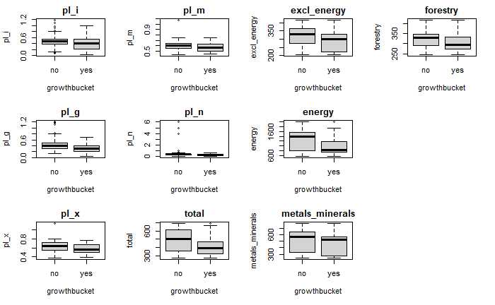

```r
plot(metals_minerals ~ growthbucket, main = "metals_minerals")
plot(forestry ~ growthbucket, main = "forestry")
```

8. The t-test results are in accordance with the observations from the box plots in this case.

```r
test4 = manova(cbind(pl_i, pl_g, pl_x, pl_m, pl_n, total, excl_energy, energy, metals_minerals, forestry) ~ growthbucket, data = recession)

summary.aov(test4)
```

```
 Response pl_i :
              Df Sum Sq  Mean Sq F value   Pr(>F)
growthbucket   1 0.1818 0.181793  9.0814 0.002718 **
Residuals    484 9.6888 0.020018
---
Signif. codes:  0 ‘***’ 0.001 ‘**’ 0.01 ‘*’ 0.05 ‘.’ 0.1 ‘ ’ 1

 Response pl_g :
              Df  Sum Sq Mean Sq F value    Pr(>F)
growthbucket   1  0.3317 0.33175  13.235 0.0003043 ***
Residuals    484 12.1322 0.02507
---
Signif. codes:  0 ‘***’ 0.001 ‘**’ 0.01 ‘*’ 0.05 ‘.’ 0.1 ‘ ’ 1

 Response pl_x :
              Df Sum Sq  Mean Sq F value   Pr(>F)
growthbucket   1 0.0766 0.076552  7.1086 0.007928 **
Residuals    484 5.2122 0.010769
---
Signif. codes:  0 ‘***’ 0.001 ‘**’ 0.01 ‘*’ 0.05 ‘.’ 0.1 ‘ ’ 1

 Response pl_m :
              Df  Sum Sq   Mean Sq F value  Pr(>F)
growthbucket   1 0.02504 0.0250378  4.3237 0.03811 *
Residuals    484 2.80276 0.0057908
---
Signif. codes:  0 ‘***’ 0.001 ‘**’ 0.01 ‘*’ 0.05 ‘.’ 0.1 ‘ ’ 1

 Response pl_n :
              Df Sum Sq Mean Sq F value Pr(>F)
growthbucket   1  0.299 0.29950  2.0052 0.1574
Residuals    484 72.291 0.14936

 Response total :
              Df  Sum Sq Mean Sq F value   Pr(>F)
growthbucket   1  155683  155683  9.0387 0.002781 **
Residuals    484 8336452   17224
---
Signif. codes:  0 ‘***’ 0.001 ‘**’ 0.01 ‘*’ 0.05 ‘.’ 0.1 ‘ ’ 1

```

[output cut: 12 more lines]

```
Signif. codes:  0 ‘***’ 0.001 ‘**’ 0.01 ‘*’ 0.05 ‘.’ 0.1 ‘ ’ 1

 Response metals_minerals :
              Df   Sum Sq Mean Sq F value  Pr(>F)
growthbucket   1   170771  170771  5.7591 0.01678 *
Residuals    484 14351654   29652
---
Signif. codes:  0 ‘***’ 0.001 ‘**’ 0.01 ‘*’ 0.05 ‘.’ 0.1 ‘ ’ 1

 Response forestry :
              Df Sum Sq Mean Sq F value  Pr(>F)
growthbucket   1   8270  8269.6   4.239 0.04004 *
Residuals    484 944192  1950.8
---
Signif. codes:  0 ‘***’ 0.001 ‘**’ 0.01 ‘*’ 0.05 ‘.’ 0.1 ‘ ’ 1
```

1. The observations from the box plots indicates a slight difference with excl_energy_change, energy_change, agriculture_change, fish_change and total change. The rest of features seem to have a significant difference with the outcome variable except fish_change.

```r
par(mfcol=c(3,4))
plot(agriculture ~ growthbucket, main = "agriculture")
plot(fish ~ growthbucket, main = "fish")
```

```r
plot(total_change ~ growthbucket, main = "total_change")
plot(excl_energy_change ~ growthbucket, main = "excl_energy_change")
```

```r
plot(energy_change ~ growthbucket, main = "energy_change")
plot(metals_minerals_change ~ growthbucket, main = "metals_minerals_change")
```

```r
plot(forestry_change ~ growthbucket, main = "forestry_change")
plot(agriculture_change ~ growthbucket, main = "agriculture_change")
```

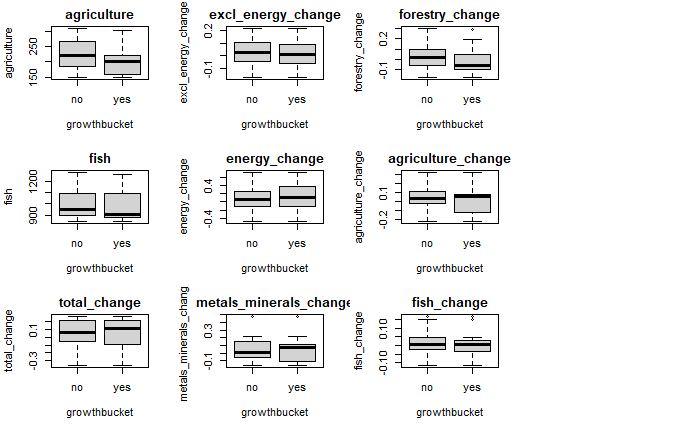

```r
plot(fish_change ~ growthbucket, main = "fish_change")
```

10. The t-test shows that agriculture, forestry_change and fish_change have a statistical difference with growthbucket.

```r
test5 = manova(cbind(agriculture, fish, total_change, excl_energy_change, energy_change, metals_minerals_change, forestry_change, agriculture_change, fish_change) ~ growthbucket, data = recession)

summary.aov(test5)
```

```
 Response agriculture :
              Df  Sum Sq Mean Sq F value Pr(>F)
growthbucket   1   18790 18790.2  7.6797 0.0058 **
Residuals    484 1184222  2446.7
---
Signif. codes:  0 ‘***’ 0.001 ‘**’ 0.01 ‘*’ 0.05 ‘.’ 0.1 ‘ ’ 1

 Response fish :
              Df  Sum Sq Mean Sq F value Pr(>F)
growthbucket   1   22553   22553  1.1489 0.2843
Residuals    484 9500559   19629

 Response total_change :
              Df  Sum Sq  Mean Sq F value Pr(>F)
growthbucket   1  0.0037 0.003677  0.1084 0.7421
Residuals    484 16.4209 0.033927

 Response excl_energy_change :
              Df Sum Sq  Mean Sq F value Pr(>F)
growthbucket   1 0.0243 0.024272  2.1813 0.1403
Residuals    484 5.3857 0.011128

 Response energy_change :
              Df Sum Sq  Mean Sq F value Pr(>F)
growthbucket   1  0.068 0.067690  0.8132 0.3676
Residuals    484 40.287 0.083238

 Response metals_minerals_change :
              Df  Sum Sq   Mean Sq F value Pr(>F)
growthbucket   1  0.0035 0.0034777  0.1517 0.6971
Residuals    484 11.0969 0.0229274

 Response forestry_change :
              Df Sum Sq  Mean Sq F value  Pr(>F)
growthbucket   1 0.0698 0.069769  4.1601 0.04193 *
Residuals    484 8.1172 0.016771
---
Signif. codes:  0 ‘***’ 0.001 ‘**’ 0.01 ‘*’ 0.05 ‘.’ 0.1 ‘ ’ 1

 Response agriculture_change :
              Df Sum Sq  Mean Sq F value Pr(>F)
growthbucket   1 0.0173 0.017292  1.0705 0.3013
Residuals    484 7.8178 0.016152

 Response fish_change :
              Df  Sum Sq  Mean Sq F value  Pr(>F)
growthbucket   1 0.03569 0.035692   6.093 0.01392 *
Residuals    484 2.83519 0.005858
---
Signif. codes:  0 ‘***’ 0.001 ‘**’ 0.01 ‘*’ 0.05 ‘.’ 0.1 ‘ ’ 1
```

7. Let’s split the data set into 80% training and 20% test. Each of the next predictive models will use a set of synthetic data created with the help of the method “smote” to address the imbalance in the outcome variable noticed on question 4.

```r
library(DMwR)
library(caret)

#split the data set into training and test
inTrain = createDataPartition(recession$growthbucket, p=0.8, list=FALSE)

recession_train = recession[inTrain,]
recession_test = recession[-inTrain,]

detach(recession)
attach(recession_train)
```

#Section 3. Creating Predictive Models

The classification, regularization and ensemble models will be built with the scaled numeric features performed using the “scale” method in the train function of caret. The Kappa metric will be preferred instead of accuracy because it is a better gauge of the model performance when facing class imbalance. The Area Under Curve (AUC) statistics will also be computed as a way to gauge the predictive value of the models. The False Positive Rate (FPR) and False Negative Rate (FNR) will be calculated so that to confirm how the model does in its classification ability. A new variable called aucTotal will be created for the sole purpose of keeping a tracability of each model’s AUC for comparison.

## Section 3.1 Classification models

8. KNN model
1. KNN Without PCA

This KNN model will be built without using the Principal Component Analysis(PCA). The value of K selected here was 7.

```r
set.seed(1)

knn_model = train(growthbucket~., data = recession_train, trControl = trainControl("cv", number=10,
                  sampling = "smote"),preProcess=c("center","scale"), method="knn", metric = "Kappa" )
knn_model
```

```
k-Nearest Neighbors

390 samples
 49 predictor
  2 classes: 'no', 'yes'

Pre-processing: centered (49), scaled (49)
Resampling: Cross-Validated (10 fold)
Summary of sample sizes: 352, 351, 351, 351, 350, 351, ...
Addtional sampling using SMOTE prior to pre-processing

Resampling results across tuning parameters:

  k  Accuracy   Kappa
  5  0.7002159  0.0836587
  7  0.7388900  0.1674856
  9  0.7259244  0.1605186

Kappa was used to select the optimal model using the largest value.
The final value used for the model was k = 7.
```

Let’s use the best model to predict recession. The kappa statistic is at 0.17.

```r
predictions_knn=predict(knn_model,recession_test)
confusionMatrix(predictions_knn,recession_test$growthbucket)
```

```
Confusion Matrix and Statistics

          Reference
Prediction no yes
       no  58   1
       yes 31   6

               Accuracy : 0.6667
                 95% CI : (0.5631, 0.7596)
    No Information Rate : 0.9271
    P-Value [Acc > NIR] : 1

                  Kappa : 0.1711

 Mcnemar's Test P-Value : 2.951e-07

            Sensitivity : 0.6517
            Specificity : 0.8571
         Pos Pred Value : 0.9831
         Neg Pred Value : 0.1622
             Prevalence : 0.9271
         Detection Rate : 0.6042
   Detection Prevalence : 0.6146
      Balanced Accuracy : 0.7544

       'Positive' Class : no
```

The AUC points to the model being an excellent classifier and suggests a very good FPR which should be confirmed in the next set of codes.

```r
library(ROCR)

#Let's compute the AUC
knn_predictions_prob = predict(knn_model, recession_test, type="prob")
head(knn_predictions_prob)
```

|  | no | yes |
| --- | --- | --- |
| 1 | 1.0000000 | 0.0000000 |
| 2 | 0.1428571 | 0.8571429 |
| 3 | 0.1428571 | 0.8571429 |
| 4 | 0.1428571 | 0.8571429 |
| 5 | 0.2857143 | 0.7142857 |
| 6 | 0.2857143 | 0.7142857 |

```r
pred_m_knn = prediction(knn_predictions_prob$yes,recession_test$growthbucket)
knn_auc = performance(pred_m_knn, measure = "auc")@y.values
knn_auc
```

```
[[1]]
[1] 0.8370787
```

```r
#keep track of AUC
aucTotal = cbind(knn_auc)
```

```r
t = table(predictions_knn,recession_test$growthbucket)
FPR = t[1,2] / (t[1,2] + t[1,1]) #false positive rate
FNR = t[2,1] / (t[2,1] + t[2,2]) #false negative rate
error = (t[1,2] + t[2,1]) / (t[1,1] + t[1,2] + t[2,1] + t[2,2])

FPR
```

```
[1] 0.01694915
```

```r
FNR
```

```
[1] 0.8378378
```

```r
error
```

```
[1] 0.3333333
```

3. KNN with PCA

When PCA is added to select features with the best chances of predictability, the best k is at 7.

```r
set.seed(1)

knn_modelPCA = train(growthbucket~., data = recession_train,
                     trControl = trainControl("cv", number=10, sampling = "smote"),                                                 preProcess=c("center","scale", "pca"), method="knn", metric="Kappa")
knn_model
```

```
k-Nearest Neighbors

390 samples
 49 predictor
  2 classes: 'no', 'yes'

Pre-processing: centered (49), scaled (49)
Resampling: Cross-Validated (10 fold)
Summary of sample sizes: 352, 351, 351, 351, 350, 351, ...
Addtional sampling using SMOTE prior to pre-processing

Resampling results across tuning parameters:

  k  Accuracy   Kappa
  5  0.7002159  0.0836587
  7  0.7388900  0.1674856
  9  0.7259244  0.1605186

Kappa was used to select the optimal model using the largest value.
The final value used for the model was k = 7.
```

Let’s use the best model to predict recession. There is no change in the Kappa statistics which is still at 0.17.

```r
predictions_knnPCA = predict(knn_modelPCA,recession_test)
confusionMatrix(predictions_knnPCA,recession_test$growthbucket)
```

```
Confusion Matrix and Statistics

          Reference
Prediction no yes
       no  58   1
       yes 31   6

               Accuracy : 0.6667
                 95% CI : (0.5631, 0.7596)
    No Information Rate : 0.9271
    P-Value [Acc > NIR] : 1

                  Kappa : 0.1711

 Mcnemar's Test P-Value : 2.951e-07

            Sensitivity : 0.6517
            Specificity : 0.8571
         Pos Pred Value : 0.9831
         Neg Pred Value : 0.1622
             Prevalence : 0.9271
         Detection Rate : 0.6042
   Detection Prevalence : 0.6146
      Balanced Accuracy : 0.7544

       'Positive' Class : no
```

The AUC is also high and similar to that of the KNN model without PCA.

```r
knnPCA_predictions_prob = predict(knn_modelPCA, recession_test, type="prob")
head(knnPCA_predictions_prob)
```

|  | no | yes |
| --- | --- | --- |
| 1 | 1.0000000 | 0.0000000 |
| 2 | 0.1428571 | 0.8571429 |
| 3 | 0.2857143 | 0.7142857 |
| 4 | 0.1428571 | 0.8571429 |
| 5 | 0.2857143 | 0.7142857 |
| 6 | 0.2857143 | 0.7142857 |

```r
pred_m_knnPCA = prediction(knnPCA_predictions_prob$yes,recession_test$growthbucket)
knnpca_auc = performance(pred_m_knnPCA, measure = "auc")@y.values
knnpca_auc
```

```
[[1]]
[1] 0.8603531
```

```r
#keep track of AUC
aucTotal = cbind(aucTotal, knnpca_auc)
```

Logically, the FPR did not change. However, the assessment of the model performance is the same for KNN with and without PCA which is not very good.

```r
t = table(predictions_knnPCA,recession_test$growthbucket)
FPR = t[1,2] / (t[1,2] + t[1,1]) #false positive rate
FNR = t[2,1] / (t[2,1] + t[2,2]) #false negative rate
error = (t[1,2] + t[2,1]) / (t[1,1] + t[1,2] + t[2,1] + t[2,2])

FPR
```

```
[1] 0.01694915
```

```r
FNR
```

```
[1] 0.8378378
```

```r
error
```

```
[1] 0.3333333
```

9. Naive Bayes
1. Naive Bayes without PCA.

We let caret auto tune the model. It appears the auto tuned parameters were o for laplace, TRUE for usekernel and 1 for adjust.

```r
set.seed(1)

nbModel = train(growthbucket~., data = recession_train,
                trControl = trainControl("cv", number=10, sampling = "smote"),                                                        preProcess=c("center","scale"), method="naive_bayes", metric="Kappa")
nbModel
```

```
Naive Bayes

390 samples
 49 predictor
  2 classes: 'no', 'yes'

Pre-processing: centered (49), scaled (49)
Resampling: Cross-Validated (10 fold)
Summary of sample sizes: 352, 351, 351, 351, 350, 351, ...
Addtional sampling using SMOTE prior to pre-processing

Resampling results across tuning parameters:

  usekernel  Accuracy   Kappa
  FALSE      0.6439946  0.1069130
   TRUE      0.7004150  0.1417537

Tuning parameter 'laplace' was held constant at a value of 0
Tuning parameter 'adjust' was
 held constant at a value of 1
Kappa was used to select the optimal model using the largest value.
The final values used for the model were laplace = 0, usekernel = TRUE and adjust = 1.
```

The kappa statistic of 0.25 is better than that of KNN with PCA.

```r
predictions_nb = predict(nbModel,recession_test)
confusionMatrix(predictions_nb,recession_test$growthbucket)
```

```
Confusion Matrix and Statistics

          Reference
Prediction no yes
       no  67   1
       yes 22   6

               Accuracy : 0.7604
                 95% CI : (0.6625, 0.8417)
    No Information Rate : 0.9271
    P-Value [Acc > NIR] : 1

                  Kappa : 0.2561

 Mcnemar's Test P-Value : 3.042e-05

            Sensitivity : 0.7528
            Specificity : 0.8571
         Pos Pred Value : 0.9853
         Neg Pred Value : 0.2143
             Prevalence : 0.9271
         Detection Rate : 0.6979
   Detection Prevalence : 0.7083
      Balanced Accuracy : 0.8050

       'Positive' Class : no
```

The AUC is high but lower than that of KNN model with PCA.

```r
nb_predictions_prob = predict(nbModel, recession_test, type="prob")
head(nb_predictions_prob)
```

|  | no | yes |
| --- | --- | --- |
| 1 | 1.000000e+00 | 3.596241e-68 |
| 2 | 1.862725e-11 | 1.000000e+00 |
| 3 | 4.582184e-09 | 1.000000e+00 |
| 4 | 1.010007e-11 | 1.000000e+00 |
| 5 | 1.255011e-11 | 1.000000e+00 |
| 6 | 5.226872e-10 | 1.000000e+00 |

```r
pred_m_nb = prediction(nb_predictions_prob$yes,recession_test$growthbucket)
nb_auc = performance(pred_m_nb, measure = "auc")@y.values
nb_auc
```

```
[[1]]
[1] 0.8298555
```

```r
#keep track of AUC
aucTotal = cbind(aucTotal, nb_auc)
```

The FPR for the model is 0.01.

```r
t = table(predictions_nb,recession_test$growthbucket)
FPR = t[1,2] / (t[1,2] + t[1,1]) #false positive rate
FNR = t[2,1] / (t[2,1] + t[2,2]) #false negative rate
error = (t[1,2] + t[2,1]) / (t[1,1] + t[1,2] + t[2,1] + t[2,2])

FPR
```

```
[1] 0.01470588
```

```r
FNR
```

```
[1] 0.7857143
```

```r
error
```

```
[1] 0.2395833
```

2. Naive Bayes with PCA.

We will also let caret auto tune the model

```r
set.seed(1)

nbModelPCA = train(growthbucket~., data = recession_train,
                   trControl = trainControl("cv",number=10, sampling = "smote"),
                   preProcess=c("center","scale", "pca"), method="naive_bayes", metric="Kappa")
nbModelPCA
```

```
Naive Bayes

390 samples
 49 predictor
  2 classes: 'no', 'yes'

Pre-processing: centered (49), scaled (49), principal component signal extraction (49)
Resampling: Cross-Validated (10 fold)
Summary of sample sizes: 352, 351, 351, 351, 350, 351, ...
Addtional sampling using SMOTE prior to pre-processing

Resampling results across tuning parameters:

  usekernel  Accuracy   Kappa
  FALSE      0.7437483  0.08284272
   TRUE      0.7723516  0.13760567

Tuning parameter 'laplace' was held constant at a value of 0
Tuning parameter 'adjust' was
 held constant at a value of 1
Kappa was used to select the optimal model using the largest value.
The final values used for the model were laplace = 0, usekernel = TRUE and adjust = 1.
```

Adding PCA to naive bayes led to a worse performance with a Kappa statistics at 0.01.

```r
predictions_nbPCA = predict(nbModelPCA,recession_test)
confusionMatrix(predictions_nbPCA,recession_test$growthbucket)
```

```
Confusion Matrix and Statistics

          Reference
Prediction no yes
       no  66   5
       yes 23   2

               Accuracy : 0.7083
                 95% CI : (0.6067, 0.7967)
    No Information Rate : 0.9271
    P-Value [Acc > NIR] : 1.000000

                  Kappa : 0.0125

 Mcnemar's Test P-Value : 0.001315

            Sensitivity : 0.7416
            Specificity : 0.2857
         Pos Pred Value : 0.9296
         Neg Pred Value : 0.0800
             Prevalence : 0.9271
         Detection Rate : 0.6875
   Detection Prevalence : 0.7396
      Balanced Accuracy : 0.5136

       'Positive' Class : no
```

Logically the AUC tanked to 0.59.

```r
nbPCA_predictions_prob = predict(nbModelPCA, recession_test, type="prob")
head(nbPCA_predictions_prob)
```

|  | no | yes |
| --- | --- | --- |
| 1 | 0.99362201 | 0.006377994 |
| 2 | 0.05544276 | 0.944557237 |
| 3 | 0.67711045 | 0.322889555 |
| 4 | 0.87214845 | 0.127851549 |
| 5 | 0.03779849 | 0.962201510 |
| 6 | 0.92585077 | 0.074149230 |

```r
pred_m_nbPCA = prediction(nbPCA_predictions_prob$yes,recession_test$growthbucket)
nbpca_auc = performance(pred_m_nbPCA, measure = "auc")@y.values
nbpca_auc
```

```
[[1]]
[1] 0.5906902
```

```r
#keep track of AUC
aucTotal = cbind(aucTotal, nbpca_auc)
```

The FPR of 0.07 is high.

```r
t = table(predictions_nbPCA,recession_test$growthbucket)
FPR = t[1,2] / (t[1,2] + t[1,1]) #false positive rate
FNR = t[2,1] / (t[2,1] + t[2,2]) #false negative rate
error = (t[1,2] + t[2,1]) / (t[1,1] + t[1,2] + t[2,1] + t[2,2])

FPR
```

```
[1] 0.07042254
```

```r
FNR
```

```
[1] 0.92
```

```r
error
```

```
[1] 0.2916667
```

## Section 3.2 Regularization Models

The following regularization models will not be used with PCA. This is because the coefficients show the weights for principal components instead of the original predictors. Therefore, the coefficients cannot be properly interpreted with PCA.

10. Lasso Logistic Regression with tuned hyper parameters

```r
set.seed(1)

lassoModel  = train(growthbucket~., data = recession_train,
                    trControl= trainControl("cv", number = 10, sampling = "smote"),
                    preProcess=c("center","scale"), method = "glmnet", metric="Kappa",
                    tuneGrid= expand.grid(alpha = 1, lambda = 10^seq(-3, 3, length = 100)), maxit=1000000)

lassoModel
```

```
glmnet

390 samples
 49 predictor
  2 classes: 'no', 'yes'

Pre-processing: centered (49), scaled (49)
Resampling: Cross-Validated (10 fold)
Summary of sample sizes: 352, 351, 351, 351, 350, 351, ...
Addtional sampling using SMOTE prior to pre-processing

Resampling results across tuning parameters:

  lambda        Accuracy   Kappa
  1.000000e-03  0.7818927   0.15603076
  1.149757e-03  0.7844568   0.15658277
  1.321941e-03  0.7818927   0.15411195
  1.519911e-03  0.7793927   0.16152202
  1.747528e-03  0.7768927   0.15931271
  2.009233e-03  0.7743927   0.15609580
  2.310130e-03  0.7770243   0.15953445
  2.656088e-03  0.7846525   0.16821068
  3.053856e-03  0.7796559   0.16650578
  3.511192e-03  0.7797874   0.14119943
  4.037017e-03  0.7720918   0.12808515
  4.641589e-03  0.7693927   0.12123023
  5.336699e-03  0.7643286   0.12059681
  6.135907e-03  0.7565047   0.11619891
  7.054802e-03  0.7487449   0.11428352
  8.111308e-03  0.7564372   0.11720774
  9.326033e-03  0.7564372   0.11720774
  1.072267e-02  0.7616329   0.11972595
  1.232847e-02  0.7643961   0.14012639
  1.417474e-02  0.7772200   0.18005666
  1.629751e-02  0.7849123   0.18685823
  1.873817e-02  0.7899764   0.19092345
  2.154435e-02  0.7848482   0.18305339
  2.477076e-02  0.7847841   0.16959445
  2.848036e-02  0.7822166   0.16627647
  3.274549e-02  0.7873448   0.18528725
```

[output cut: 63 more lines]

```
  2.477076e+02  0.9205668   0.00000000
  2.848036e+02  0.9205668   0.00000000
  3.274549e+02  0.9205668   0.00000000
  3.764936e+02  0.9205668   0.00000000
  4.328761e+02  0.9205668   0.00000000
  4.977024e+02  0.9205668   0.00000000
  5.722368e+02  0.9205668   0.00000000
  6.579332e+02  0.9205668   0.00000000
  7.564633e+02  0.9205668   0.00000000
  8.697490e+02  0.9205668   0.00000000
  1.000000e+03  0.9205668   0.00000000

Tuning parameter 'alpha' was held constant at a value of 1
Kappa was used to select the optimal model using the largest value.
The final values used for the model were alpha = 1 and lambda = 0.01873817.
```

The coefficients of the best tuned models show that some of the features were deemed to have low predictability value hence their coefficients were shrunk to zero.

```r
coef(lassoModel$finalModel, lassoModel$bestTune$lambda)
```

```
50 x 1 sparse Matrix of class "dgCMatrix"
                                  1
(Intercept)            -0.427343330
pop                     .
emp                     .
emp_to_pop_ratio       -0.005317278
hc                      .
ccon                    .
cda                     .
cn                      .
ck                      0.062234043
ctfp                    .
cwtfp                  -0.132883472
rconna                  .
rdana                   .
rnna                    .
rkna                    0.015374438
rtfpna                  .
rwtfpna                -0.291577786
labsh                   .
irr                    -0.222853461
delta                   .
xr                      0.215610767
pl_con                  .
pl_da                   .
pl_gdpo                 .
csh_c                  -0.005004789
csh_i                  -0.034916342
csh_g                   0.334789401
csh_x                   0.014051570
csh_m                   .
csh_r                  -0.536772172
pl_c                    0.853024934
pl_i                    .
pl_g                   -0.208558994
pl_x                    .
pl_m                    .
pl_n                   -0.272337878
total                   .
excl_energy             .
energy                 -0.425050715
metals_minerals         .
forestry                .
agriculture            -0.197561756
fish                    .
total_change            .
excl_energy_change     -0.333609593
energy_change           0.616815245
metals_minerals_change  .
forestry_change        -0.421195517
agriculture_change      .
fish_change            -0.103463933
```

```r
#prediction on test data
lassoPredictions  = predict(lassoModel, recession_test)
confusionMatrix(lassoPredictions, recession_test$growthbucket)
```

```
Confusion Matrix and Statistics

          Reference
Prediction no yes
       no  67   0
       yes 22   7

               Accuracy : 0.7708
                 95% CI : (0.6739, 0.8505)
    No Information Rate : 0.9271
    P-Value [Acc > NIR] : 1

                  Kappa : 0.3075

 Mcnemar's Test P-Value : 7.562e-06

            Sensitivity : 0.7528
            Specificity : 1.0000
         Pos Pred Value : 1.0000
         Neg Pred Value : 0.2414
             Prevalence : 0.9271
         Detection Rate : 0.6979
   Detection Prevalence : 0.6979
      Balanced Accuracy : 0.8764

       'Positive' Class : no
```

The AUC is the highest at 0.89 and tells that the model is very close to being an outstanding classifier when it comes to distinguising between true and false positives.

```r
lasso_predictions_prob = predict(lassoModel, recession_test, type="prob")
head(lasso_predictions_prob)
```

|  | no | yes |
| --- | --- | --- |
| 1 | 0.5270403781 | 0.4729596 |
| 2 | 0.0004883018 | 0.9995117 |
| 3 | 0.2992602216 | 0.7007398 |
| 4 | 0.0299560472 | 0.9700440 |
| 5 | 0.6529342126 | 0.3470658 |
| 6 | 0.6767795841 | 0.3232204 |

```r
pred_m_lasso = prediction(lasso_predictions_prob$yes,recession_test$growthbucket)
lasso_auc = performance(pred_m_lasso, measure = "auc")@y.values
lasso_auc
```

```
[[1]]
[1] 0.8988764
```

```r
#keep track of AUC
aucTotal = cbind(aucTotal, lasso_auc)
```

In this case the FPR is at 0 and is in accordance with the very high AUC.

```r
t = table(lassoPredictions,recession_test$growthbucket)
FPR = t[1,2] / (t[1,2] + t[1,1]) #false positive rate
FNR = t[2,1] / (t[2,1] + t[2,2]) #false negative rate
error = (t[1,2] + t[2,1]) / (t[1,1] + t[1,2] + t[2,1] + t[2,2])

FPR
```

```
[1] 0
```

```r
FNR
```

```
[1] 0.7586207
```

```r
error
```

```
[1] 0.2291667
```

11. Ridge Logistic Regression with tuned hyper parameters ended up with lambda at 0.4

```r
set.seed(1)

ridgeModel  = train(growthbucket~., data = recession_train,
                    trControl= trainControl("cv", number = 10, sampling = "smote"),
                    preProcess=c("center","scale"), method = "glmnet", metric="Kappa",
                    tuneGrid= expand.grid(alpha = 0, lambda = 10^seq(-3, 3, length = 100)), maxit=1000000)
ridgeModel
```

```
glmnet

390 samples
 49 predictor
  2 classes: 'no', 'yes'

Pre-processing: centered (49), scaled (49)
Resampling: Cross-Validated (10 fold)
Summary of sample sizes: 352, 351, 351, 351, 350, 351, ...
Addtional sampling using SMOTE prior to pre-processing

Resampling results across tuning parameters:

  lambda        Accuracy   Kappa
  1.000000e-03  0.7617004   0.12640800
  1.149757e-03  0.7617004   0.12640800
  1.321941e-03  0.7617004   0.12640800
  1.519911e-03  0.7617004   0.12640800
  1.747528e-03  0.7617004   0.12640800
  2.009233e-03  0.7617004   0.12640800
  2.310130e-03  0.7617004   0.12640800
  2.656088e-03  0.7617004   0.12640800
  3.053856e-03  0.7617004   0.12640800
  3.511192e-03  0.7617004   0.12640800
  4.037017e-03  0.7617004   0.12640800
  4.641589e-03  0.7617004   0.12640800
  5.336699e-03  0.7617004   0.12640800
  6.135907e-03  0.7617004   0.12640800
  7.054802e-03  0.7617004   0.12640800
  8.111308e-03  0.7617004   0.12640800
  9.326033e-03  0.7617004   0.12640800
  1.072267e-02  0.7617004   0.12640800
  1.232847e-02  0.7617004   0.12640800
  1.417474e-02  0.7590688   0.12338458
  1.629751e-02  0.7590688   0.12338458
  1.873817e-02  0.7616329   0.12402498
  2.154435e-02  0.7668286   0.14699137
  2.477076e-02  0.7693927   0.16876477
  2.848036e-02  0.7668286   0.16629396
  3.274549e-02  0.7693286   0.16830237
```

[output cut: 63 more lines]

```
  2.477076e+02  0.9205668   0.00000000
  2.848036e+02  0.9205668   0.00000000
  3.274549e+02  0.9205668   0.00000000
  3.764936e+02  0.9205668   0.00000000
  4.328761e+02  0.9205668   0.00000000
  4.977024e+02  0.9205668   0.00000000
  5.722368e+02  0.9205668   0.00000000
  6.579332e+02  0.9205668   0.00000000
  7.564633e+02  0.9205668   0.00000000
  8.697490e+02  0.9205668   0.00000000
  1.000000e+03  0.9205668   0.00000000

Tuning parameter 'alpha' was held constant at a value of 0
Kappa was used to select the optimal model using the largest value.
The final values used for the model were alpha = 0 and lambda = 0.4037017.
```

```r
#prediction on test data
ridgePredictions  = predict(ridgeModel, recession_test)
confusionMatrix(ridgePredictions, recession_test$growthbucket)
```

```
Confusion Matrix and Statistics

          Reference
Prediction no yes
       no  71   1
       yes 18   6

               Accuracy : 0.8021
                 95% CI : (0.7083, 0.8764)
    No Information Rate : 0.9271
    P-Value [Acc > NIR] : 0.9999829

                  Kappa : 0.3091

 Mcnemar's Test P-Value : 0.0002419

            Sensitivity : 0.7978
            Specificity : 0.8571
         Pos Pred Value : 0.9861
         Neg Pred Value : 0.2500
             Prevalence : 0.9271
         Detection Rate : 0.7396
   Detection Prevalence : 0.7500
      Balanced Accuracy : 0.8274

       'Positive' Class : no
```

The AUC comes to be at 0.90 which is an outstanding classifier.

```r
ridge_predictions_prob = predict(ridgeModel, recession_test, type="prob")
head(ridge_predictions_prob)
```

|  | no | yes |
| --- | --- | --- |
| 1 | 0.59973063 | 0.4002694 |
| 2 | 0.02656283 | 0.9734372 |
| 3 | 0.47585783 | 0.5241422 |
| 4 | 0.09882543 | 0.9011746 |
| 5 | 0.54523457 | 0.4547654 |
| 6 | 0.49984072 | 0.5001593 |

```r
pred_m_ridge = prediction(ridge_predictions_prob$yes,recession_test$growthbucket)
ridge_auc = performance(pred_m_ridge, measure = "auc")@y.values
ridge_auc
```

```
[[1]]
[1] 0.9069021
```

```r
#keep track of AUC
aucTotal = cbind(aucTotal, ridge_auc)
```

The FPR is slightly higher at 0.01.

```r
t = table(ridgePredictions, recession_test$growthbucket)
FPR = t[1,2] / (t[1,2] + t[1,1]) #false positive rate
FNR = t[2,1] / (t[2,1] + t[2,2]) #false negative rate
error = (t[1,2] + t[2,1]) / (t[1,1] + t[1,2] + t[2,1] + t[2,2])

FPR
```

```
[1] 0.01388889
```

```r
FNR
```

```
[1] 0.75
```

```r
error
```

```
[1] 0.1979167
```

12. Enet Logistic Regression with tuned hyper parameters

```r
set.seed(1)

enetModel  = train(growthbucket~., data = recession_train,
                   trControl= trainControl("cv", number = 10, sampling = "smote"),
                   preProcess=c("center","scale"), method = "glmnet", metric="Kappa",
                   tuneGrid= expand.grid(alpha =seq(0,1, length=10), lambda = 10^seq(-3, 3, length = 100)),                              maxit=1000000)
enetModel
```

```
glmnet

390 samples
 49 predictor
  2 classes: 'no', 'yes'

Pre-processing: centered (49), scaled (49)
Resampling: Cross-Validated (10 fold)
Summary of sample sizes: 352, 351, 351, 351, 350, 351, ...
Addtional sampling using SMOTE prior to pre-processing

Resampling results across tuning parameters:

  alpha      lambda        Accuracy   Kappa
  0.0000000  1.000000e-03  0.7488158   0.085377086
  0.0000000  1.149757e-03  0.7488158   0.085377086
  0.0000000  1.321941e-03  0.7488158   0.085377086
  0.0000000  1.519911e-03  0.7488158   0.085377086
  0.0000000  1.747528e-03  0.7488158   0.085377086
  0.0000000  2.009233e-03  0.7488158   0.085377086
  0.0000000  2.310130e-03  0.7488158   0.085377086
  0.0000000  2.656088e-03  0.7488158   0.085377086
  0.0000000  3.053856e-03  0.7488158   0.085377086
  0.0000000  3.511192e-03  0.7488158   0.085377086
  0.0000000  4.037017e-03  0.7488158   0.085377086
  0.0000000  4.641589e-03  0.7488158   0.085377086
  0.0000000  5.336699e-03  0.7488158   0.085377086
  0.0000000  6.135907e-03  0.7488158   0.085377086
  0.0000000  7.054802e-03  0.7488158   0.085377086
  0.0000000  8.111308e-03  0.7488158   0.085377086
  0.0000000  9.326033e-03  0.7488158   0.085377086
  0.0000000  1.072267e-02  0.7488158   0.085377086
  0.0000000  1.232847e-02  0.7488158   0.085377086
  0.0000000  1.417474e-02  0.7461842   0.082353672
  0.0000000  1.629751e-02  0.7461842   0.082353672
  0.0000000  1.873817e-02  0.7461842   0.082353672
  0.0000000  2.154435e-02  0.7488158   0.081521939
  0.0000000  2.477076e-02  0.7538799   0.085908262
  0.0000000  2.848036e-02  0.7538799   0.085908262
  0.0000000  3.274549e-02  0.7564440   0.102473371
```

[output cut: 213 more lines]

```
  0.2222222  2.310130e-01  0.8056174   0.143288520
  0.2222222  2.656088e-01  0.8133097   0.114237923
  0.2222222  3.053856e-01  0.8235054   0.077153508
  0.2222222  3.511192e-01  0.8465891   0.078645288
  0.2222222  4.037017e-01  0.8541498   0.007750439
  0.2222222  4.641589e-01  0.8899258   0.016438980
  0.2222222  5.336699e-01  0.9077463  -0.018557377
  0.2222222  6.135907e-01  0.9205668   0.000000000
  0.2222222  7.054802e-01  0.9205668   0.000000000
  0.2222222  8.111308e-01  0.9205668   0.000000000
  0.2222222  9.326033e-01  0.9205668   0.000000000
 [ reached getOption("max.print") -- omitted 750 rows ]

Kappa was used to select the optimal model using the largest value.
The final values used for the model were alpha = 0.5555556 and lambda = 0.1149757.
```

The Kappa statistics decreased to 0.23 in comparison to Lasso and Ridge. Since elastic net uses a combination of lasso and ridge, it is possible some of the feature elimination processes of lasso led to a loss of information. A model that eliminates features is not ideal given the high class imbalance.

```r
#prediction on test data
enetPredictions  = predict(enetModel, recession_test)
confusionMatrix(enetPredictions, recession_test$growthbucket)
```

```
Confusion Matrix and Statistics

          Reference
Prediction no yes
       no  70   2
       yes 19   5

               Accuracy : 0.7812
                 95% CI : (0.6853, 0.8592)
    No Information Rate : 0.9271
    P-Value [Acc > NIR] : 0.9999987

                  Kappa : 0.2364

 Mcnemar's Test P-Value : 0.0004803

            Sensitivity : 0.7865
            Specificity : 0.7143
         Pos Pred Value : 0.9722
         Neg Pred Value : 0.2083
             Prevalence : 0.9271
         Detection Rate : 0.7292
   Detection Prevalence : 0.7500
      Balanced Accuracy : 0.7504

       'Positive' Class : no
```

The AUC is still high though at 0.86.

```r
enet_predictions_prob = predict(enetModel, recession_test, type="prob")
head(enet_predictions_prob)
```

|  | no | yes |
| --- | --- | --- |
| 1 | 0.70449426 | 0.2955057 |
| 2 | 0.05272177 | 0.9472782 |
| 3 | 0.49658636 | 0.5034136 |
| 4 | 0.13412236 | 0.8658776 |
| 5 | 0.62674372 | 0.3732563 |
| 6 | 0.50654304 | 0.4934570 |

```r
pred_m_enet = prediction(enet_predictions_prob$yes,recession_test$growthbucket)
enet_auc = performance(pred_m_enet, measure = "auc")@y.values
enet_auc
```

```
[[1]]
[1] 0.8635634
```

```r
#keep track of AUC
aucTotal = cbind(aucTotal, enet_auc)
```

The FPR for the model is at 0.02

```r
t = table(enetPredictions, recession_test$growthbucket)
FPR = t[1,2] / (t[1,2] + t[1,1]) #false positive rate
FNR = t[2,1] / (t[2,1] + t[2,2]) #false negative rate
error = (t[1,2] + t[2,1]) / (t[1,1] + t[1,2] + t[2,1] + t[2,2])

FPR
```

```
[1] 0.02777778
```

```r
FNR
```

```
[1] 0.7916667
```

```r
error
```

```
[1] 0.21875
```

## Section 3.3 Ensemble Models

13. Random Forest:

```r
set.seed(1)

rfModel  = train(growthbucket~., data = recession_train,
                       trControl= trainControl("cv", number = 10, sampling = "smote"),
                       method = "rf",  metric="Kappa",
                       tunegrid = expand.grid(mtry= c(2, 4, 8, 16)), Importance = "T", maxit=1000000)
rfModel
```

```
Random Forest

390 samples
 49 predictor
  2 classes: 'no', 'yes'

No pre-processing
Resampling: Cross-Validated (10 fold)
Summary of sample sizes: 352, 351, 351, 351, 350, 351, ...
Addtional sampling using SMOTE

Resampling results across tuning parameters:

  mtry  Accuracy   Kappa
   2    0.8362652  0.1766025
  25    0.8237045  0.1671764
  49    0.8104892  0.1448517

Kappa was used to select the optimal model using the largest value.
The final value used for the model was mtry = 2.
```

Let’s take a look at the variable importance which tells us which variable were deemed to be better predictors for the random forest model.

```r
varImp(rfModel)
```

```
rf variable importance

  only 20 most important variables shown (out of 49)
```

|  | Overall |
| --- | --- |
| csh_r | 100.00000 |
| pl_c | 44.88460 |
| rconna | 40.35097 |
| xr | 39.44240 |
| rdana | 39.42118 |
| pl_con | 38.77954 |
| delta | 37.09486 |
| agriculture | 35.74670 |
| cwtfp | 35.65410 |
| pl_g | 34.26285 |

[output cut: 10 more lines]

The Kappa statistics for the random forest model is at 0.54, the highest so far indicating a moderate agreement between the actual and predicted values.

```r
#prediction on test data
rfPredictions  = predict(rfModel, recession_test)
confusionMatrix(rfPredictions, recession_test$growthbucket)
```

```
Confusion Matrix and Statistics

          Reference
Prediction no yes
       no  84   2
       yes  5   5

               Accuracy : 0.9271
                 95% CI : (0.8555, 0.9702)
    No Information Rate : 0.9271
    P-Value [Acc > NIR] : 0.5988

                  Kappa : 0.5496

 Mcnemar's Test P-Value : 0.4497

            Sensitivity : 0.9438
            Specificity : 0.7143
         Pos Pred Value : 0.9767
         Neg Pred Value : 0.5000
             Prevalence : 0.9271
         Detection Rate : 0.8750
   Detection Prevalence : 0.8958
      Balanced Accuracy : 0.8291

       'Positive' Class : no
```

The AUC of 0.90 points to a model which is excellent at identifying positive values

```r
rf_predictions_prob = predict(rfModel, recession_test, type="prob")
head(rf_predictions_prob)
```

|  | no | yes |
| --- | --- | --- |
| 2 | 0.796 | 0.204 |
| 8 | 0.506 | 0.494 |
| 20 | 0.520 | 0.480 |
| 28 | 0.564 | 0.436 |
| 33 | 0.458 | 0.542 |
| 34 | 0.424 | 0.576 |

```r
pred_m_rf = prediction(rf_predictions_prob$yes,recession_test$growthbucket)
rf_auc = performance(pred_m_rf, measure = "auc")@y.values
rf_auc
```

```
[[1]]
[1] 0.9028892
```

```r
#keep track of AUC
aucTotal = cbind(aucTotal, rf_auc)
```

The FPR is at 0.02

```r
t = table(rfPredictions, recession_test$growthbucket)
FPR = t[1,2] / (t[1,2] + t[1,1]) #false positive rate
FNR = t[2,1] / (t[2,1] + t[2,2]) #false negative rate
error = (t[1,2] + t[2,1]) / (t[1,1] + t[1,2] + t[2,1] + t[2,2])

FPR
```

```
[1] 0.02325581
```

```r
FNR
```

```
[1] 0.5
```

```r
error
```

```
[1] 0.07291667
```

14. Gradient Boost

```r
set.seed(1)

gbmModel  = train(growthbucket~., data = recession_train,
                   trControl= trainControl("cv", number = 10, sampling = "smote"),
                   preProcess=c("center","scale"), method = "gbm", metric="Kappa")
gbmModel
```

```
Stochastic Gradient Boosting

390 samples
 49 predictor
  2 classes: 'no', 'yes'

Pre-processing: centered (49), scaled (49)
Resampling: Cross-Validated (10 fold)
Summary of sample sizes: 352, 351, 351, 351, 350, 351, ...
Addtional sampling using SMOTE prior to pre-processing

Resampling results across tuning parameters:

  interaction.depth  n.trees  Accuracy   Kappa
  1                   50      0.7749123  0.1656055
  1                  100      0.7725472  0.1629464
  1                  150      0.7571626  0.1180852
  2                   50      0.8133131  0.2166954
  2                  100      0.8339642  0.2452702
  2                  150      0.8235762  0.1883117
  3                   50      0.7952294  0.1394586
  3                  100      0.8079858  0.1569858
  3                  150      0.8131815  0.1297196

Tuning parameter 'shrinkage' was held constant at a value of 0.1
Tuning parameter
 'n.minobsinnode' was held constant at a value of 10
Kappa was used to select the optimal model using the largest value.
The final values used for the model were n.trees = 100, interaction.depth = 2, shrinkage = 0.1
 and n.minobsinnode = 10.
```

```r
#prediction on test data
gbmPredictions  = predict(gbmModel, recession_test)
confusionMatrix(gbmPredictions, recession_test$growthbucket)
```

```
Confusion Matrix and Statistics

          Reference
Prediction no yes
       no  77   3
       yes 12   4

               Accuracy : 0.8438
                 95% CI : (0.7554, 0.9098)
    No Information Rate : 0.9271
    P-Value [Acc > NIR] : 0.99846

                  Kappa : 0.2742

 Mcnemar's Test P-Value : 0.03887

            Sensitivity : 0.8652
            Specificity : 0.5714
         Pos Pred Value : 0.9625
         Neg Pred Value : 0.2500
             Prevalence : 0.9271
         Detection Rate : 0.8021
   Detection Prevalence : 0.8333
      Balanced Accuracy : 0.7183

       'Positive' Class : no
```

The resulting AUC is at 0.82 indicating the model has an 82% chance of distinguishing between false positive and true positive.

```r
gbm_predictions_prob = predict(gbmModel, recession_test, type="prob")
head(gbm_predictions_prob)
```

|  | no | yes |
| --- | --- | --- |
| 1 | 0.8929228 | 0.1070772 |
| 2 | 0.3105501 | 0.6894499 |
| 3 | 0.6062201 | 0.3937799 |
| 4 | 0.7656581 | 0.2343419 |
| 5 | 0.6458959 | 0.3541041 |
| 6 | 0.4758123 | 0.5241877 |

```r
pred_m_gbm = prediction(gbm_predictions_prob$yes,recession_test$growthbucket)
gb_auc = performance(pred_m_gbm, measure = "auc")@y.values
gb_auc
```

```
[[1]]
[1] 0.8218299
```

```r
#keep track of AUC
aucTotal = cbind(aucTotal, gb_auc)
```

The FPR is at 0.03

```r
t = table(gbmPredictions, recession_test$growthbucket)
FPR = t[1,2] / (t[1,2] + t[1,1]) #false positive rate
FNR = t[2,1] / (t[2,1] + t[2,2]) #false negative rate
error = (t[1,2] + t[2,1]) / (t[1,1] + t[1,2] + t[2,1] + t[2,2])

FPR
```

```
[1] 0.0375
```

```r
FNR
```

```
[1] 0.75
```

```r
error
```

```
[1] 0.15625
```

15. ada boost

```r
set.seed(1)

adaModel  = train(growthbucket~., data = recession_train,
                  trControl= trainControl("cv", number = 10, sampling = "smote"),
                  preProcess=c("center","scale"), method = "adaboost", metric="Kappa")
adaModel
```

```
AdaBoost Classification Trees

390 samples
 49 predictor
  2 classes: 'no', 'yes'

Pre-processing: centered (49), scaled (49)
Resampling: Cross-Validated (10 fold)
Summary of sample sizes: 352, 351, 351, 351, 350, 351, ...
Addtional sampling using SMOTE prior to pre-processing

Resampling results across tuning parameters:

  nIter  method         Accuracy   Kappa
   50    Adaboost.M1    0.8026687  0.11562387
   50    Real adaboost  0.8590891  0.17037586
  100    Adaboost.M1    0.8315283  0.13898568
  100    Real adaboost  0.8747368  0.24001910
  150    Adaboost.M1    0.7901046  0.09021507
  150    Real adaboost  0.8617173  0.20201970

Kappa was used to select the optimal model using the largest value.
The final values used for the model were nIter = 100 and method = Real adaboost.
```

The Kappa statistics for this model is at 0.39 and the second highest.

```r
#prediction on test data
adaPredictions  = predict(adaModel, recession_test)
confusionMatrix(adaPredictions, recession_test$growthbucket)
```

```
Confusion Matrix and Statistics

          Reference
Prediction no yes
       no  79   2
       yes 10   5

               Accuracy : 0.875
                 95% CI : (0.7918, 0.9337)
    No Information Rate : 0.9271
    P-Value [Acc > NIR] : 0.97778

                  Kappa : 0.3943

 Mcnemar's Test P-Value : 0.04331

            Sensitivity : 0.8876
            Specificity : 0.7143
         Pos Pred Value : 0.9753
         Neg Pred Value : 0.3333
             Prevalence : 0.9271
         Detection Rate : 0.8229
   Detection Prevalence : 0.8438
      Balanced Accuracy : 0.8010

       'Positive' Class : no
```

The AUC though is one of the lowest at 0.69

```r
ada_predictions_prob = predict(adaModel, recession_test, type="prob")
head(ada_predictions_prob)
```

|  | no | yes |
| --- | --- | --- |
| 1 | 1.000000e+00 | 0.000000e+00 |
| 2 | -4.699903e+15 | 4.699903e+15 |
| 3 | 7.128287e+14 | -7.128287e+14 |
| 4 | 2.460594e+15 | -2.460594e+15 |
| 5 | 4.919216e+15 | -4.919216e+15 |
| 6 | 2.515287e+15 | -2.515287e+15 |

```r
pred_m_ada = prediction(ada_predictions_prob$yes,recession_test$growthbucket)
ada_auc = performance(pred_m_ada, measure = "auc")@y.values
ada_auc
```

```
[[1]]
[1] 0.6966292
```

```r
#keep track of AUC
aucTotal = cbind(aucTotal, ada_auc)
```

The FPR is at 0.02

```r
t = table(adaPredictions, recession_test$growthbucket)
FPR = t[1,2] / (t[1,2] + t[1,1]) #false positive rate
FNR = t[2,1] / (t[2,1] + t[2,2]) #false negative rate
error = (t[1,2] + t[2,1]) / (t[1,1] + t[1,2] + t[2,1] + t[2,2])

FPR
```

```
[1] 0.02469136
```

```r
FNR
```

```
[1] 0.6666667
```

```r
error
```

```
[1] 0.125
```

16. Tree bag

```r
set.seed(1)

treebagModel  = train(growthbucket~., data = recession_train,
                  trControl= trainControl("cv", number = 10, sampling = "smote"),
                  preProcess=c("center","scale"), method = "treebag", nbagg = 25, metrics = "kappa")
treebagModel
```

```
Bagged CART

390 samples
 49 predictor
  2 classes: 'no', 'yes'

Pre-processing: centered (49), scaled (49)
Resampling: Cross-Validated (10 fold)
Summary of sample sizes: 352, 351, 351, 351, 350, 351, ...
Addtional sampling using SMOTE prior to pre-processing

Resampling results:

  Accuracy   Kappa
  0.7773482  0.09859238
```

The kappa statistics is at 0.21

```r
#prediction on test data
treebagpredictions  = predict(treebagModel, recession_test)
confusionMatrix(treebagpredictions, recession_test$growthbucket)
```

```
Confusion Matrix and Statistics

          Reference
Prediction no yes
       no  68   2
       yes 21   5

               Accuracy : 0.7604
                 95% CI : (0.6625, 0.8417)
    No Information Rate : 0.9271
    P-Value [Acc > NIR] : 0.9999999

                  Kappa : 0.2126

 Mcnemar's Test P-Value : 0.0001746

            Sensitivity : 0.7640
            Specificity : 0.7143
         Pos Pred Value : 0.9714
         Neg Pred Value : 0.1923
             Prevalence : 0.9271
         Detection Rate : 0.7083
   Detection Prevalence : 0.7292
      Balanced Accuracy : 0.7392

       'Positive' Class : no
```

The AUC in this case is at 0.84

```r
treebag_predictions_prob = predict(treebagModel, recession_test, type="prob")
head(treebag_predictions_prob)
```

|  | no | yes |
| --- | --- | --- |
| 1 | 0.84 | 0.16 |
| 2 | 0.40 | 0.60 |
| 3 | 0.48 | 0.52 |
| 4 | 0.48 | 0.52 |
| 5 | 0.24 | 0.76 |
| 6 | 0.52 | 0.48 |

```r
pred_m_treebag = prediction(treebag_predictions_prob$yes,recession_test$growthbucket)
treebag_auc = performance(pred_m_treebag, measure = "auc")@y.values
treebag_auc
```

```
[[1]]
[1] 0.8410915
```

```r
#keep track of AUC
aucTotal = cbind(aucTotal, treebag_auc)
```

With the FPR at 0.02

```r
t = table(treebagpredictions, recession_test$growthbucket)
FPR = t[1,2] / (t[1,2] + t[1,1]) #false positive rate
FNR = t[2,1] / (t[2,1] + t[2,2]) #false negative rate
error = (t[1,2] + t[2,1]) / (t[1,1] + t[1,2] + t[2,1] + t[2,2])

FPR
```

```
[1] 0.02857143
```

```r
FNR
```

```
[1] 0.8076923
```

```r
error
```

```
[1] 0.2395833
```

17. Using the resamples() function, I was able to compare the Kappa statistics for all models used so far. The first thing to note is that the model with the highest kappa, Random Forest, doesn’t have the highest mean Kappa for in-sample data. The second highest Kappa, adaboost had the second highest mean Kappa. The third highest mean Kappa was the ridge model which also had the third highest out of sample Kappa. The wide gap between the mean Kappa and out of sample of Kappa of the random forest model is a concern since the model does take a subset of features to build several decision trees. It could also mean that the model is biased toward the majority classifier. The high out of sample Kappa might be deceptive and affected by the class imbalance.

```r
compare = resamples(list(k = knn_model, kpca = knn_modelPCA, nb = nbModel, nbpca = nbModelPCA,
                        l = lassoModel, r = ridgeModel, e = enetModel,
                        rf = rfModel, gbm = gbmModel, ada = adaModel, treeb = treebagModel   )  )

summary(compare)
```

```
Call:
summary.resamples(object = compare)

Models: k, kpca, nb, nbpca, l, r, e, rf, gbm, ada, treeb
Number of resamples: 10

Accuracy
           Min.   1st Qu.    Median      Mean   3rd Qu.      Max. NA's
k     0.6666667 0.6687500 0.7307692 0.7388900 0.7884615 0.8461538    0
kpca  0.6410256 0.6793269 0.7435897 0.7361910 0.7844130 0.8717949    0
nb    0.5641026 0.6410256 0.6889339 0.7004150 0.7948718 0.8205128    0
nbpca 0.6250000 0.7692308 0.7820513 0.7723516 0.8141026 0.8461538    0
l     0.6666667 0.7756410 0.7948718 0.7899764 0.8193320 0.8974359    0
r     0.7435897 0.7756410 0.8205128 0.8130567 0.8367072 0.9230769    0
e     0.7250000 0.8169703 0.8333333 0.8258738 0.8461538 0.9230769    0
rf    0.7250000 0.7948718 0.8205128 0.8362652 0.8901822 0.9230769    0
gbm   0.6750000 0.8012821 0.8717949 0.8339642 0.8717949 0.9210526    0
ada   0.7948718 0.8269231 0.8846154 0.8747368 0.9230769 0.9473684    0
treeb 0.6500000 0.7307692 0.7820513 0.7773482 0.8193320 0.8974359    0

Kappa
             Min.     1st Qu.     Median       Mean   3rd Qu.      Max. NA's
k      0.01169591  0.09877874 0.13360474 0.16748564 0.2905334 0.3275862    0
kpca   0.00000000  0.09877874 0.14767157 0.15480122 0.2079488 0.3809524    0
nb     0.00000000  0.10344828 0.10784314 0.14175370 0.2134284 0.2834646    0
nbpca -0.10638298  0.03843504 0.11839080 0.13760567 0.2905334 0.3275862    0
l      0.01169591  0.10344828 0.17769505 0.19092345 0.2820429 0.3870968    0
r      0.07874016  0.14255319 0.22610294 0.22983611 0.2834646 0.4328358    0
e      0.07874016  0.14255319 0.17021277 0.22309440 0.2698386 0.5301205    0
rf    -0.10638298 -0.04642709 0.20920139 0.17660253 0.3413579 0.5301205    0
gbm    0.07874016  0.11091954 0.21686747 0.24527021 0.3399312 0.6274510    0
ada   -0.10638298  0.10151515 0.26543425 0.24001910 0.4252703 0.5301205    0
treeb -0.12598425 -0.06222204 0.09109422 0.09859238 0.2120276 0.4468085    0
```

18. A comparison of all AUC confirms that the model with the highest Kappa so far, random forest, had he second highest value. Taken separately, these numbers would tell that the random forest is the best. However, the issue of class imbalance would affect the decision of which model is better.

```r
aucTotal
```

```
     knn_auc   knnpca_auc nb_auc    nbpca_auc lasso_auc ridge_auc enet_auc  rf_auc    gb_auc
[1,] 0.8370787 0.8603531  0.8298555 0.5906902 0.8988764 0.9069021 0.8635634 0.9028892 0.8218299
     ada_auc   treebag_auc
[1,] 0.6966292 0.8410915
```

## Section 3.4 Neural Network Model

19. Let’s split the train set further into a train/validation set

```r
inTrain = createDataPartition(recession_train$growthbucket, p=0.9, list=FALSE)
recession_val = recession_train[-inTrain,]
recession_trainNeural = recession_train[inTrain,]
```

20. Scale all numeric variables except the outcome variable

```r
recession_trainScaled = scale(recession_trainNeural[-50])
col_means_train = attr(recession_trainScaled, "scaled:center")
col_stddevs_train = attr(recession_trainScaled, "scaled:scale")
recession_valScaled = scale(recession_val[-50], center = col_means_train, scale = col_stddevs_train)
recession_testScaled = scale(recession_test[-50], center = col_means_train, scale = col_stddevs_train)



#label with the growthbucket to predict
#Let's also change the label back to numeric so it can be fed to the neural network
recession_trainScaledlabel = ifelse(recession_trainNeural$growthbucket=="no", 0, 1)
recession_valScaledlabel = ifelse(recession_val$growthbucket=="no", 0, 1)
recession_testScaledlabel = ifelse(recession_test$growthbucket=="no", 0, 1)
```

21. Let’s build a simple neural network model. I will start with 2 hidden layers of 64 neurons each. There will be a drop out layer for each hidden layer with a drop out rate of 0.4. For this model, the AUC will be chosen as metric.

```r
library(keras)

model  = keras_model_sequential() %>%
  layer_dense(units = 64, activation = 'relu',input_shape= dim(recession_trainScaled)[2]) %>%
  layer_dropout(0.4)%>%
  layer_dense(units = 64, activation = 'relu') %>%
  layer_dropout(0.4)%>%
  layer_dense(units = 1, activation  = 'sigmoid')

model %>% compile(loss = 'binary_crossentropy', optimizer = 'adam', metrics = c('AUC') )

set.seed(128)
history = model %>% fit(recession_trainScaled, recession_trainScaledlabel ,
                         epochs = 50, batch_size=100,
                        validation_data = list(recession_valScaled, recession_valScaledlabel)
                        )
```

22. A plot of the model shows the AUC higher for the training than the validation.

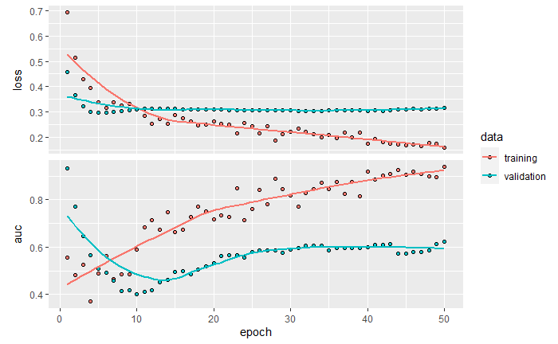

```r
plot(history)
```

23. Let’s auto tune the hyper parameters using flags

```r
install.packages("tfruns")
library(tfruns)
run = tuning_run("recessionFlags.R", flags = list(nodes1 = c(32, 64, 128, 196),drop_out1 = c(0.2, 0.3, 0.4, 0.5), nodes2 = c(32, 64, 128, 196),drop_out2 = c(0.2, 0.3, 0.4, 0.5), learning_rate= c(0.01, 0.05, 0.001, 0.0001), batch_size=c(50,100,250, 500),epochs=c(30,50,100),activation1=c("relu","sigmoid","tanh"), activation2 = "sigmoid"),
                 sample = .005)
```

24. The model with the best run would be the one with the lowest validation loss and highest validation AUC. That model can be found at directory 142.

```r
which.min(run$metric_val_loss)
```

```
[1] 142
```

```r
which.max(run$metric_val_auc)
```

```
[1] 142
```

```r
view_run(run$run_dir[142])
```

26. Let’s use the tuned parameters from the best run to build a new model that will be run on both the training and validation data combined. Then the model will be tested against the test data.

```r
#merge train and validation into one train set. Also merge the labels
recessionMergedTrain = rbind(recession_trainScaled, recession_valScaled)
recessionMergedTrainLabel = as.numeric(c(recession_trainScaledlabel, recession_valScaledlabel))

model  = keras_model_sequential() %>%
  layer_dense(units = 32, activation = 'relu',input_shape= dim(recession_trainScaled)[2]) %>%
  layer_dropout(0.3)%>%
  layer_dense(units = 64, activation = 'relu') %>%
  layer_dropout(0.2)%>%
  layer_dense(units = 1, activation  = 'sigmoid')

model %>% compile(loss = 'binary_crossentropy',
                  optimizer = optimizer_adam(lr = 0.05),
                  metrics = c('AUC') )

set.seed(128)
history = model %>% fit(recessionMergedTrain, recessionMergedTrainLabel ,
                         epochs = 100, batch_size=100,
                        )
```

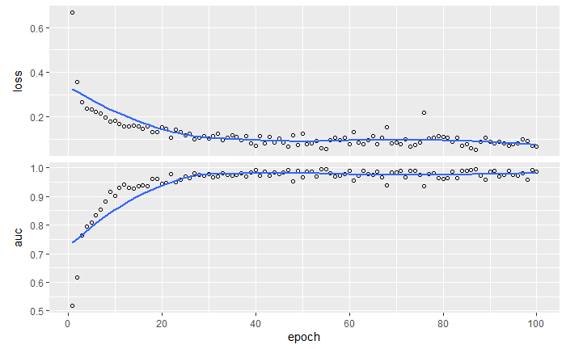

28. Let’s evaluate the tuned model on the test data. Despite having a high AUC, this model did poorly on the out of sample data with a Kappa statistics of 0.09.

```r
#get the prediction class, change to factor then do a confusion matrix for the kappa
class_pred = model %>% predict_classes(recession_testScaled)
#let's also change back to no and yes for better readability
t1 = as.factor( ifelse(class_pred==0, "no", "yes" ))
t2 = as.factor(ifelse(recession_testScaledlabel==0, "no", "yes"))
confusionMatrix(t1, t2)
```

```
Confusion Matrix and Statistics

          Reference
Prediction no yes
       no  84   6
       yes  5   1

               Accuracy : 0.8854
                 95% CI : (0.8042, 0.9414)
    No Information Rate : 0.9271
    P-Value [Acc > NIR] : 0.9534

                  Kappa : 0.0928

 Mcnemar's Test P-Value : 1.0000

            Sensitivity : 0.9438
            Specificity : 0.1429
         Pos Pred Value : 0.9333
         Neg Pred Value : 0.1667
             Prevalence : 0.9271
         Detection Rate : 0.8750
   Detection Prevalence : 0.9375
      Balanced Accuracy : 0.5433

       'Positive' Class : no
```

```r
t = table(t1, t2)
FPR = t[1,2] / (t[1,2] + t[1,1]) #false positive rate
FNR = t[2,1] / (t[2,1] + t[2,2]) #false negative rate
error = (t[1,2] + t[2,1]) / (t[1,1] + t[1,2] + t[2,1] + t[2,2])

FPR
```

```
[1] 0.06666667
```

```r
FNR
```

```
[1] 0.8333333
```

```r
error
```

```
[1] 0.1145833
```